# Assignment 4

STATS 369

Camilo Berrios

```r
# Set code to show
knitr::opts_chunk$set(echo = TRUE)

# Load libraries
library(tidyverse)
library(ggplot2)
library(glmnet)
library(ranger)
library(caret)
library(glmnet)
library(ranger)
library(xgboost)
library(dplyr)
```

## Task 1: Data import

#### a. Set a random seed using the last 3 digits of your student ID.

```r
set.seed(645)
```

#### b. Load the data bank.csv into the R. (Hint: the data file is NOT comma delimited).

```r
bank_data <- read.table("bank_marketing.csv", sep = ";", header = TRUE)
head(bank_data, 5)
```

```
##   age       job marital   education default housing loan   contact month
## 1  56 housemaid married    basic.4y      no      no   no telephone   may
## 2  57  services married high.school unknown      no   no telephone   may
## 3  37  services married high.school      no     yes   no telephone   may
## 4  40    admin. married    basic.6y      no      no   no telephone   may
## 5  56  services married high.school      no      no  yes telephone   may
##   day_of_week duration campaign pdays previous    poutcome emp_var_rate
## 1         mon      261        1   999        0 nonexistent          1.1
## 2         mon      149        1   999        0 nonexistent          1.1
## 3         mon      226        1   999        0 nonexistent          1.1
## 4         mon      151        1   999        0 nonexistent          1.1
## 5         mon      307        1   999        0 nonexistent          1.1
##   cons_price_idx cons_conf_idx euribor3m nr_employed  y
## 1         93.994         -36.4     4.857        5191 no
## 2         93.994         -36.4     4.857        5191 no
## 3         93.994         -36.4     4.857        5191 no
## 4         93.994         -36.4     4.857        5191 no
## 5         93.994         -36.4     4.857        5191 no
```

#### c. Read the data dictionary here, which variable(s) should we discarded if we want to build a model to predict y?

According to the data dictionary, the variable “duration” should not be used to create a predictive model. The data dictionary notes that “duration” highly affects the output target “y” and should only be included for benchmark purposes.

However, it’s also important to perform further analysis and explore the relationships between the remaining variables and the target variable “y” through statistical tests and exploratory data analysis. While “duration” is a clear candidate for exclusion, the relevance of other variables should be assessed to ensure we have a well-considered set of predictors for our predictive model.

## Task 2. Data exploration

#### a. Discard the variable(s) from 1.c. Code the response y as 0 if y=no; and 1 if y=yes. Then randomly split this data into 90% training and 10% testing (Hint: the data is not balanced). Given each data frame meaningful names such as train.df and test.df.

```r
# Discard the "duration" variable
bank_data <- bank_data[, -which(names(bank_data) == "duration")]

# response variable "y" as 0 for "no" and 1 for "yes"
bank_data$y <- ifelse(bank_data$y == "no", 0, 1)

# split data with stratification to keep the proportions
index_train <- createDataPartition(bank_data$y, p = 0.9, list = FALSE, times = 1)
train.df <- bank_data[index_train, ]
test.df <- bank_data[-index_train, ]
```

```r
# Split train.df into two subsets: y=0 and y=1
train_y0 <- train.df[train.df$y == 0, ]
train_y1 <- train.df[train.df$y == 1, ]

# sample 50% of each subset
n_samples <- min(nrow(train_y0), nrow(train_y1))  # Ensure equal sample sizes
train_y0 <- train_y0[sample(nrow(train_y0), n_samples, replace = TRUE), ]
train_y1 <- train_y1[sample(nrow(train_y1), n_samples, replace = TRUE), ]

# create a new balanced train data set
train.df <- rbind(train_y0, train_y1)
```

```r
# distribution in the original dataset
class_distribution_original <- table(bank_data$y)
class_distribution_original
```

```
##
##     0     1
## 36531  4636
```

```r
# distribution in the testing set
class_distribution_testing <- table(test.df$y)
class_distribution_testing
```

```
##
##    0    1
## 3659  457
```

```r
# distribution in the training set
class_distribution_training <- table(train.df$y)
class_distribution_training
```

```
##
##    0    1
## 4179 4179
```

#### b. Produce at least two sensible plots or summary tables to demonstrate the exploration of relationships between the various predictors with the response y. You shall explore at least one qualitative variable and one quantitative variable from the data set.

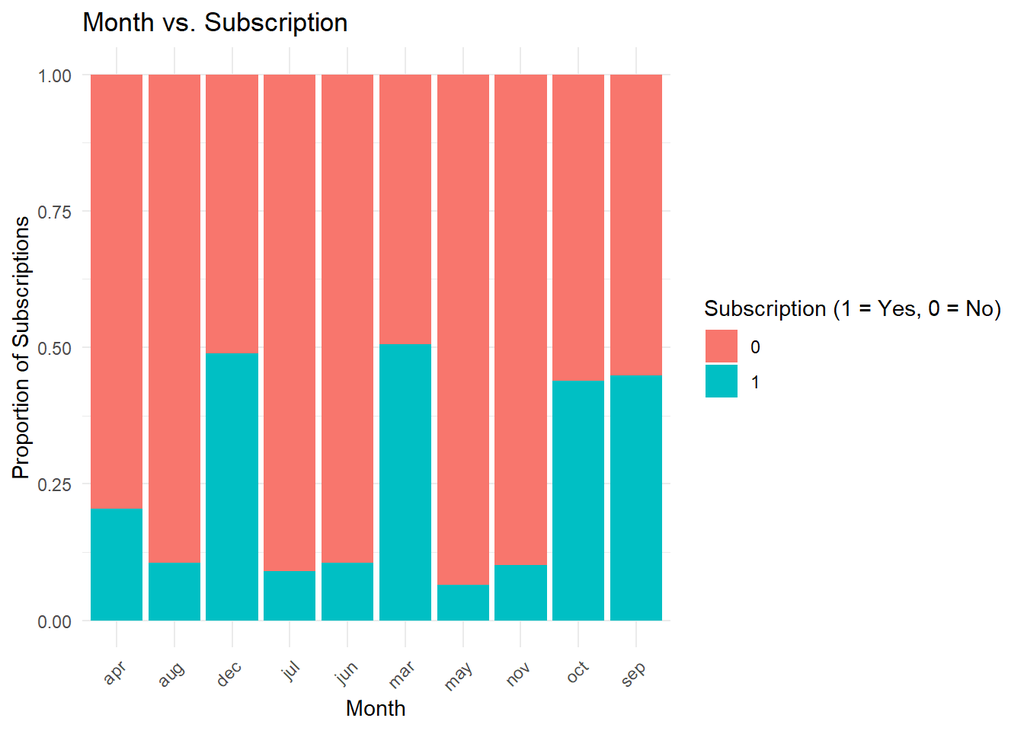

```r
# Create a bar plot of month vs. subscription
month_plot <- ggplot(data = bank_data, aes(x = month, fill = as.factor(y))) +
  geom_bar(position = "fill") +
  labs(title = "Month vs. Subscription",
       x = "Month",
       y = "Proportion of Subscriptions",
       fill = "Subscription (1 = Yes, 0 = No)") +
  theme_minimal() +
  theme(axis.text.x = element_text(angle = 45, hjust = 1))  # Rotate x-axis labels for readability

# Display the plot
print(month_plot)
```

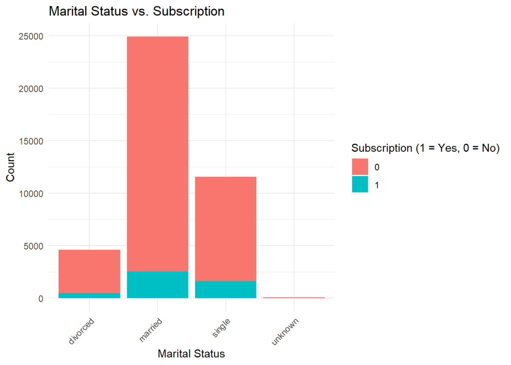

```r
# Create a stacked bar plot of marital vs subscription
marital_stacked_bar <- ggplot(data = bank_data, aes(x = marital, fill = as.factor(y))) +
  geom_bar() +
  labs(title = "Marital Status vs. Subscription",
       x = "Marital Status",
       y = "Count",
       fill = "Subscription (1 = Yes, 0 = No)") +
  theme_minimal() +
  theme(axis.text.x = element_text(angle = 45, hjust = 1))

# Display the stacked bar plot
print(marital_stacked_bar)
```

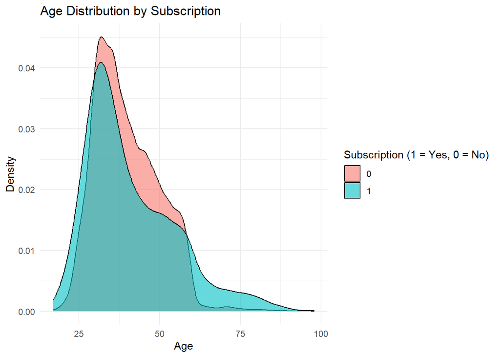

```r
# Create a density plot of age for subscribers and non-subscribers
age_density_plot <- ggplot(data = bank_data, aes(x = age, fill = as.factor(y))) +
  geom_density(alpha = 0.6) +
  labs(title = "Age Distribution by Subscription",
       x = "Age",
       y = "Density",
       fill = "Subscription (1 = Yes, 0 = No)") +
  theme_minimal()

# Display the density plot
print(age_density_plot)
```

#### c. Comments on each of the outputs produced in 2.b.

The Plot Month vs. Subscription shows the proportion of subscribers by month. It shows that some month of the year explain or have a greater proportion of subscriptions for example december, march, october and september have proportions around 50% while the other months have less than 25% ob subscriptions.

Age Distribution by Subscription shows the density of subscriptions by age. It shows that the probability of getting a subscription are very similar for ages below 60 years old, however, the probability of getting a subscription when the age is greater than 60 years old shows that it’s very likely that the person would get a subscription. It seems like older people get relatively more subscription than younger people.

#### d. Make a guess on what three variables may be important in predicting y. (Note: this is NOT a coding question).

The month variable appears to be a significant predictor. Some months, such as December, March, October, and September, show a higher proportion of subscriptions, while others have lower proportions. The timing of the marketing campaign throughout the year could be a crucial factor in predicting whether a client subscribes.

Age is another potential important predictor. The density plot suggests that older individuals, particularly those over 60 years old, are more likely to subscribe to a term deposit. Age may play a role in the decision-making process of clients regarding term deposits.

## Task 3: Modelling

#### a. Fit each of the following modeling approaches to train.df. Show your R codes and outputs.

#### i. Logistic regression with glm (Hint: glm is part of the {stats} package that is loaded automatically when R starts up; you may want to use ?glm to check how to fit a logistic model and generate predictions)

```r
# logistic regression model
model_glm <- glm(y ~ ., data = train.df, family = binomial)
summary(model_glm)
```

```
##
## Call:
## glm(formula = y ~ ., family = binomial, data = train.df)
##
## Coefficients: (1 not defined because of singularities)
##                                Estimate Std. Error z value Pr(>|z|)
## (Intercept)                  -1.811e+02  5.414e+01  -3.346 0.000821 ***
## age                          -5.903e-03  3.213e-03  -1.837 0.066196 .
## jobblue-collar               -9.613e-02  9.796e-02  -0.981 0.326428
## jobentrepreneur              -3.945e-02  1.505e-01  -0.262 0.793230
## jobhousemaid                 -3.919e-01  1.986e-01  -1.973 0.048474 *
## jobmanagement                 7.324e-02  1.085e-01   0.675 0.499578
## jobretired                    3.817e-01  1.481e-01   2.578 0.009946 **
## jobself-employed             -2.895e-01  1.520e-01  -1.905 0.056739 .
## jobservices                  -9.893e-02  1.065e-01  -0.929 0.352777
## jobstudent                   -1.985e-01  1.727e-01  -1.150 0.250344
## jobtechnician                 5.977e-02  9.270e-02   0.645 0.519069
## jobunemployed                 1.404e-01  1.737e-01   0.808 0.418963
## jobunknown                    1.386e-01  3.370e-01   0.411 0.680845
## maritalmarried                1.792e-01  8.541e-02   2.098 0.035939 *
## maritalsingle                 2.605e-01  9.789e-02   2.661 0.007792 **
## maritalunknown                1.122e+00  6.131e-01   1.830 0.067239 .
## educationbasic.6y            -1.545e-01  1.477e-01  -1.046 0.295749
## educationbasic.9y            -1.337e-01  1.137e-01  -1.176 0.239619
## educationhigh.school         -7.261e-02  1.153e-01  -0.630 0.529009
## educationprofessional.course -1.796e-01  1.292e-01  -1.390 0.164590
## educationuniversity.degree   -5.970e-02  1.171e-01  -0.510 0.610246
## educationunknown              3.502e-02  1.562e-01   0.224 0.822610
## defaultunknown               -2.113e-01  7.442e-02  -2.839 0.004530 **
## housingunknown               -1.214e-02  1.829e-01  -0.066 0.947105
## housingyes                    5.452e-02  5.295e-02   1.030 0.303175
## loanunknown                          NA         NA      NA       NA
## loanyes                       7.339e-02  7.298e-02   1.006 0.314556
## contacttelephone             -4.692e-01  1.041e-01  -4.508 6.53e-06 ***
## monthaug                      9.560e-01  2.105e-01   4.541 5.60e-06 ***
## monthdec                      1.010e+00  4.235e-01   2.384 0.017123 *
## monthjul                      3.709e-01  1.327e-01   2.795 0.005194 **
## monthjun                     -4.641e-01  1.888e-01  -2.458 0.013957 *
## monthmar                      1.571e+00  2.483e-01   6.325 2.52e-10 ***
## monthmay                     -4.154e-01  1.141e-01  -3.641 0.000272 ***
```

[output cut: 12 more lines]

```
## emp_var_rate                 -1.545e+00  2.157e-01  -7.161 8.00e-13 ***
## cons_price_idx                1.895e+00  3.663e-01   5.173 2.30e-07 ***
## cons_conf_idx                 5.385e-03  1.279e-02   0.421 0.673724
## euribor3m                     5.021e-01  1.827e-01   2.748 0.005994 **
## nr_employed                   4.980e-04  4.302e-03   0.116 0.907850
## ---
## Signif. codes:  0 '***' 0.001 '**' 0.01 '*' 0.05 '.' 0.1 ' ' 1
##
## (Dispersion parameter for binomial family taken to be 1)
##
##     Null deviance: 11587  on 8357  degrees of freedom
## Residual deviance:  8977  on 8308  degrees of freedom
## AIC: 9077
##
## Number of Fisher Scoring iterations: 5
```

```r
# Fit a logistic regression model with selected variables
model_glm_updated <- glm(y ~   marital +
                            + default + contact +
                           month + euribor3m  + poutcome +
                           emp_var_rate + cons_price_idx,
                         data = train.df, family = binomial)

# Summary of the updated logistic regression model
summary(model_glm_updated)
```

```
##
## Call:
## glm(formula = y ~ marital + +default + contact + month + euribor3m +
##     poutcome + emp_var_rate + cons_price_idx, family = binomial,
##     data = train.df)
##
## Coefficients:
##                       Estimate Std. Error z value Pr(>|z|)
## (Intercept)         -188.66873   15.09431 -12.499  < 2e-16 ***
## maritalmarried         0.18485    0.08396   2.202 0.027687 *
## maritalsingle          0.30156    0.09031   3.339 0.000840 ***
## maritalunknown         1.28952    0.60691   2.125 0.033609 *
## defaultunknown        -0.23780    0.07183  -3.310 0.000932 ***
## contacttelephone      -0.47061    0.09644  -4.880 1.06e-06 ***
## monthaug               1.07833    0.13670   7.888 3.07e-15 ***
## monthdec               1.00115    0.40627   2.464 0.013731 *
## monthjul               0.39332    0.12462   3.156 0.001599 **
## monthjun              -0.52134    0.13594  -3.835 0.000125 ***
## monthmar               1.61112    0.21495   7.495 6.62e-14 ***
## monthmay              -0.41834    0.09800  -4.269 1.97e-05 ***
## monthnov              -0.33362    0.14374  -2.321 0.020289 *
## monthoct               0.05418    0.19842   0.273 0.784823
## monthsep               0.14441    0.19994   0.722 0.470110
## euribor3m              0.56884    0.10787   5.273 1.34e-07 ***
## poutcomenonexistent    0.43474    0.08629   5.038 4.70e-07 ***
## poutcomesuccess        1.45711    0.15118   9.638  < 2e-16 ***
## emp_var_rate          -1.63287    0.14557 -11.217  < 2e-16 ***
## cons_price_idx         1.98661    0.15856  12.529  < 2e-16 ***
## ---
## Signif. codes:  0 '***' 0.001 '**' 0.01 '*' 0.05 '.' 0.1 ' ' 1
##
## (Dispersion parameter for binomial family taken to be 1)
##
##     Null deviance: 11587  on 8357  degrees of freedom
## Residual deviance:  9021  on 8338  degrees of freedom
## AIC: 9061
##
## Number of Fisher Scoring iterations: 5
```

It seems like droping some variables dont make a big change: AIC: 9077 vs 9061. I will keep the first model for predictions.

#### ii. Ridge regression with glmnet

```r
# Convert dataframe to a matrix
train_matrix <- as.matrix(train.df)

# Create a response vector
y_train <- train.df$y

# Fit a ridge regression model
ridge_model <- glmnet(train_matrix, y_train, alpha = 0)
```

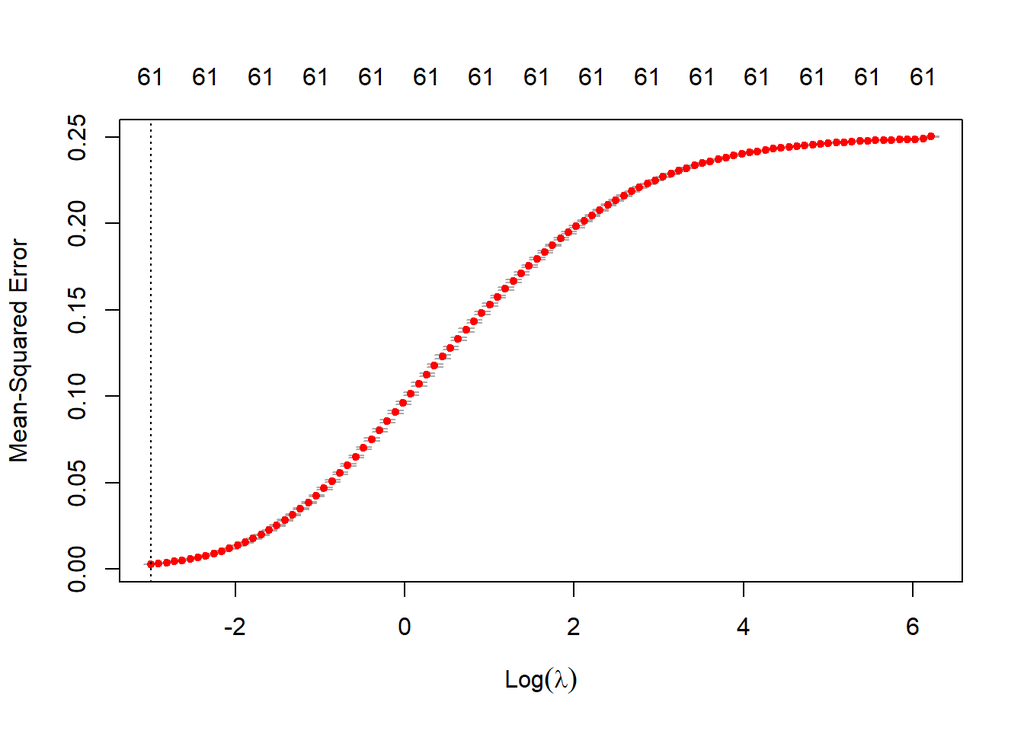

```r
# Identify categorical variables in the training dataset
categorical_vars <- sapply(train.df, is.character)
ridge_train <- train.df

# Convert categorical variables
ridge_train[categorical_vars] <- lapply(ridge_train[categorical_vars], as.factor)
train_df_dummies <- predict(dummyVars(~., data = ridge_train), newdata = ridge_train)
y_train <- as.numeric(ridge_train$y)

# ridge regression model
ridge_model <- glmnet(x = as.matrix(train_df_dummies), y = y_train, alpha = 0)

# Cross-validate the model
xval <- cv.glmnet(x = as.matrix(train_df_dummies), y = y_train, alpha = 0)
plot(xval)
```

```r
# ridge test
ridge_test <- test.df

test_matrix <- as.matrix(ridge_test)
ridge_test[categorical_vars] <- lapply(ridge_test[categorical_vars], as.factor)
test_df_dummies <- predict(dummyVars(~., data = ridge_test), newdata = ridge_test)

# Predict using the ridge regression model
predictions <- predict(ridge_model, s = xval$lambda.min, newx = as.matrix(test_df_dummies))
table(predictions>0, ridge_test$y)
```

```
##
##           0    1
##   TRUE 3659  457
```

```r
median(predictions)
```

```
## [1] 0.04189437
```

```r
table(predictions>median(predictions), ridge_test$y)
```

```
##
##            0    1
##   FALSE 2058    0
##   TRUE  1601  457
```

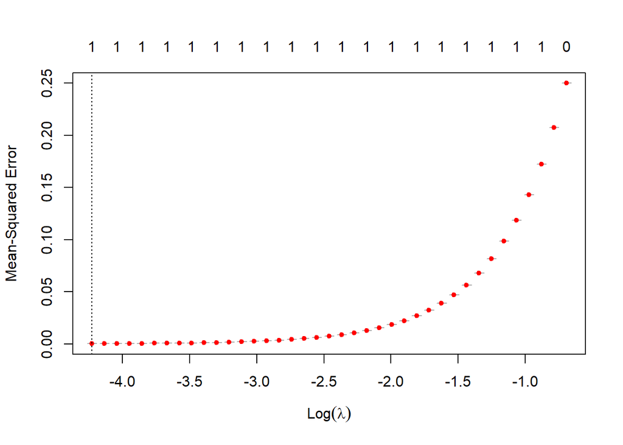

```r
Xint<-model.matrix(~.^2,data=train.df)
y<-train.df$y

fitint <-glmnet(Xint,y)
xvalint <-cv.glmnet(Xint,y)
plot(xvalint)
```

#### iii. Random Forest with ranger

```r
# Random Forest model
try(rf_model <- ranger(y ~ ., data = train.df, importance = 'impurity'))
rf_model
```

```
## Ranger result
##
## Call:
##  ranger(y ~ ., data = train.df, importance = "impurity")
##
## Type:                             Regression
## Number of trees:                  500
## Sample size:                      8358
## Number of independent variables:  19
## Mtry:                             4
## Target node size:                 5
## Variable importance mode:         impurity
## Splitrule:                        variance
## OOB prediction error (MSE):       0.131
## R squared (OOB):                  0.4760628
```

#### iv. XGBoost with xgboost

```r
train_XGB <- train.df

# List of categorical variables to convert
categorical_variables <- c("job", "marital", "education", "default", "housing", "loan", "contact", "month", "day_of_week", "poutcome")

for (var in categorical_variables) {
  if (length(train_XGB[[var]]) == nrow(train_XGB)) {
    train_XGB[[var]] <- as.numeric(factor(train_XGB[[var]]))
  } else {
    cat("Skipping variable:", var, "due to row mismatch.\n")
  }
}

# Remove the response variable from training data
y_train <- train_XGB$y
train_data <- train_XGB[, -which(names(train_XGB) == "y")]

# Convert the training data to a DMatrix
train_dmatrix <- xgb.DMatrix(data = as.matrix(train_XGB), label = y_train)

# Fit the XGBoost model
xgb_model <- xgboost(data = as.matrix(train_data), label = y_train, max_depth = 2,
               eta = 0.5, nthread = 2, nrounds = 5, objective = "binary:logistic")
```

#### b. For each of the models fitted, test the performance on test.df and produce the corresponding confusion matrix. (So you shall have one 2x2 confusion matrice per each model fitted.)

#### i. Logistic regression with glm

```r
# Predictions on the test data
test_predictions <- predict(model_glm, newdata = test.df, type = "response")

# Convert predicted probabilities to binary predictions (0 or 1)
test_predictions_binary <- ifelse(test_predictions > 0.5, 1, 0)


# Create a confusion matrix
conf_matrix <- confusionMatrix(table(test_predictions_binary, test.df$y))
conf_matrix
```

```
## Confusion Matrix and Statistics
##
##
## test_predictions_binary    0    1
##                       0 3193  187
##                       1  466  270
##
##                Accuracy : 0.8414
##                  95% CI : (0.8298, 0.8524)
##     No Information Rate : 0.889
##     P-Value [Acc > NIR] : 1
##
##                   Kappa : 0.3658
##
##  Mcnemar's Test P-Value : <2e-16
##
##             Sensitivity : 0.8726
##             Specificity : 0.5908
##          Pos Pred Value : 0.9447
##          Neg Pred Value : 0.3668
##              Prevalence : 0.8890
##          Detection Rate : 0.7758
##    Detection Prevalence : 0.8212
##       Balanced Accuracy : 0.7317
##
##        'Positive' Class : 0
##
```

#### ii. Ridge regression with glmnet

```r
Xinttest<-model.matrix(~.^2, data=test.df)
predyint<-predict(fitint, Xinttest, s=xvalint$lambda.min)
table(predyint>0, test.df$y)
```

```
##
##           0    1
##   TRUE 3659  457
```

```r
table(predyint>median(predictions), test.df$y)
```

```
##
##            0    1
##   FALSE 3659    0
##   TRUE     0  457
```

#### iii. Random Forest with ranger

```r
rf_predictions <- predict(rf_model, data = test.df)

# Extract the predicted class probabilities
predicted_probs <- as.vector(rf_predictions$predictions)

# Convert predicted probabilities to class labels (binary classification)
predicted_labels <- ifelse(predicted_probs > 0.5, 1, 0)

# Extract the actual class labels from the test data
actual_labels <- test.df$y

# Create a confusion matrix
confusion_matrix <- table(Actual = actual_labels, Predicted = predicted_labels)

# Print the confusion matrix
print(confusion_matrix)
```

```
##       Predicted
## Actual    0    1
##      0 3206  453
##      1  181  276
```

#### iv. XGBoost with xgboost

```r
test_XGB <- test.df

# List of categorical variables to convert
categorical_variables <- c("job", "marital", "education", "default", "housing", "loan", "contact", "month", "day_of_week", "poutcome")

for (var in categorical_variables) {
  if (length(test_XGB[[var]]) == nrow(test_XGB)) {
    test_XGB[[var]] <- as.numeric(factor(test_XGB[[var]]))
  } else {
    cat("Skipping variable:", var, "due to row mismatch.\n")
  }
}

# Convert response variable to a numeric vector for the test data
y_test <- test.df$y

# Remove the response variable from test data
test_data <- test_XGB[, -which(names(test.df) == "y")]

# Convert the test data to a DMatrix
test_dmatrix <- xgb.DMatrix(data = as.matrix(test_data), label = y_test)

# Make predictions using the trained XGBoost model
xgb_predictions <- predict(xgb_model, test_dmatrix)

# Convert predicted probabilities to class labels (binary classification)
predicted_labels <- ifelse(xgb_predictions > 0.5, 1, 0)

# Create a confusion matrix
confusion_matrix <- table(Actual = y_test, Predicted = predicted_labels)

# Print the confusion matrix
print(confusion_matrix)
```

```
##       Predicted
## Actual    0    1
##      0 3202  457
##      1  196  261
```